# Autonomisation politique des femmes et la mortalité maternelle

Ecrit par AZEHOUN Raïssa, DAUVERGNE Leslie, HAMERY Lorie, IZABAYO Joy, KIDINDA Nonga-Sara et PAYS Sandy

INTRODUCTION

La mortalité maternelle reste aujourd’hui l’un des indicateurs les plus alarmants des inégalités de santé à l’échelle mondiale. Chaque année, environ 287 000 femmes perdent la vie des suites de complications liées à la grossesse, à l’accouchement ou aux semaines qui suivent, alors même que la majorité de ces décès sont évitables (Organisation mondiale de la Santé [OMS], 2023). Ces décès, pour la plupart observés dans les pays à revenus faibles et intermédiaires, révèlent à la fois des défaillances dans les systèmes de santé et un manque de priorité politique pour la santé des femmes.

Traditionnellement abordée sous un angle biomédical, la question de la santé maternelle tend aujourd’hui à être élargie aux dimensions sociales, économiques et institutionnelles. Par exemple, certains pays comme la France adoptent une définition plus large de la mortalité maternelle, en incluant les décès survenus jusqu’à un an après la fin de la grossesse. Cette approche permet de mieux prendre en compte les causes indirectes, notamment psychiques, comme les troubles du post-partum, dont le suicide (INSERM, 2021 ; OMS, 2013).

Dans ce contexte, il devient essentiel de s’interroger sur les facteurs politiques susceptibles d’agir sur les résultats en santé maternelle. Plusieurs travaux empiriques ont suggéré que la représentation politique des femmes pourrait contribuer à une amélioration des conditions de santé publique. Aux États-Unis, par exemple, l’accès des femmes au vote a été suivi d’une hausse significative des dépenses en santé infantile et maternelle, avec un effet mesurable sur la survie des enfants (Miller, 2008). En Inde, l’élection de femmes à la tête de gouvernements locaux a conduit à une augmentation de l’investissement dans les infrastructures de santé et à une réduction de la mortalité maternelle (Bhalotra, Clots-Figueras, & Iyer, 2014).

Ces exemples laissent penser que la présence des femmes dans les sphères décisionnelles pourrait jouer un rôle structurant dans l’orientation des priorités budgétaires et législatives, en faveur de politiques de santé plus inclusives. L’hypothèse centrale de ce travail est que l’autonomisation politique des femmes peut contribuer à une réduction de la mortalité maternelle, en rendant les institutions plus sensibles aux besoins spécifiques des femmes.

Ce mémoire vise ainsi à répondre à la question suivante :

En quoi l’autonomisation politique des femmes influence-t-elle les politiques de santé maternelle et contribue-t-elle à réduire la mortalité maternelle à l’échelle mondiale ?

Cette problématique invite à croiser deux dimensions souvent étudiées de manière séparée : l’égalité politique entre les sexes, et la santé maternelle comme indicateur clé de développement humain. Elle repose sur l’idée que les inégalités dans la représentation politique ne sont pas seulement une question de justice démocratique, mais qu’elles ont aussi des conséquences concrètes et mesurables sur la vie et la santé des femmes (Sen & Östlin, 2008 ; UN Women, 2020).

Pour y répondre, ce travail adopte une double démarche : théorique, à travers une revue de la littérature croisant économie politique, études de genre et santé publique ; et empirique, à travers une analyse économétrique sur données de panel couvrant l’ensemble des pays du monde. Cette approche permet de tester le lien entre représentation politique féminine et mortalité maternelle, en tenant compte des principaux facteurs économiques, sanitaires et institutionnels.

Ce travail est structuré en trois parties.  
La première partie définit les concepts clés et propose une revue de la littérature mobilisant les approches institutionnelles, féministes et de santé publique.  
La deuxième partie présente la base de données utilisée, la construction des variables et la stratégie économétrique adoptée.  
Enfin, la troisième partie discute les résultats obtenus, compare les effets observés entre pays développés et pays en développement.

Ce mémoire a pour objectif d’**analyser l’effet de la représentation politique des femmes sur la mortalité maternelle à l’échelle mondiale**.  
Il s’inscrit dans une approche qui considère la santé des femmes non seulement comme une question médicale ou économique, mais aussi comme un enjeu politique. En s’appuyant sur des données de panel couvrant un large éventail de pays, cette recherche entend évaluer si et comment l’autonomisation politique des femmes contribue à la réduction des décès liés à la grossesse et à l’accouchement.

Dans ce cadre, plusieurs objectifs spécifiques sont poursuivis :  
**1.** Explorer les fondements théoriques du lien entre représentation politique féminine et santé maternelle, à travers une revue de littérature mobilisant les apports des études de genre, de l’économie politique et de la santé publique.  
**2.** Identifier les mécanismes potentiels par lesquels la présence des femmes dans les institutions politiques peut influencer les politiques de santé maternelle, qu’il s’agisse de l’allocation budgétaire, des priorités législatives ou de la visibilité accordée aux enjeux de santé reproductive.  
**3.** Tester empiriquement cette relation à partir d’un modèle économétrique, en intégrant les principaux déterminants structurels tels que le niveau de développement économique, l’espérance de vie ou la qualité des institutions.  
**4.** Comparer les effets observés entre les pays développés et ceux en développement, afin de déterminer si l’impact de l’autonomisation politique varie selon les contextes socio-économiques.

La réflexion repose sur plusieurs hypothèses formulées à la lumière de la littérature existante :  
• H1 — Hypothèse d’effet global : Une plus grande représentation politique des femmes est associée à une diminution significative de la mortalité maternelle, toutes choses égales par ailleurs.  
• H2 — Hypothèse de sensibilité politique : Les femmes occupant des fonctions électives ou exécutives sont plus susceptibles de faire avancer des politiques favorables à la santé des femmes, notamment en matière de santé reproductive.  
• H3 — Hypothèse contextuelle : L’effet de la représentation féminine est plus marqué dans les pays en développement, où les politiques de santé publique sont plus directement influencées par les priorités politiques et les allocations budgétaires.  
• H4 — Hypothèse de saturation institutionnelle : Dans les pays déjà avancés sur le plan de l’égalité politique et de l’accès aux soins, les effets marginaux d’une progression de la représentation féminine sont moins prononcés.  
Ces hypothèses guideront l’ensemble de l’analyse empirique. Elles seront testées à l’aide de modèles économétriques adaptés aux données de panel, et mises en perspective à travers une lecture critique des résultats.

# 1 Fondements conceptuels et théoriques

## 1.1 Définitions et concepts clés

Comprendre l’impact de la représentation politique des femmes sur la mortalité maternelle nécessite d’abord de clarifier les concepts mobilisés et d’analyser les mécanismes théoriques qui pourraient expliquer un tel lien. La santé maternelle, longtemps abordée sous un angle biomédical, est aujourd’hui reconnue comme dépendante d’un ensemble de facteurs sociaux, économiques, psychologiques et institutionnels. La présence accrue de femmes dans les instances politiques pourrait jouer un rôle structurant dans la transformation des priorités publiques, en particulier dans les domaines de la santé reproductive, de la santé mentale post-partum, et de la lutte contre les inégalités de genre.

L’Organisation mondiale de la santé (OMS) qualifie de **mortalité maternelle** le décès d’une femme pendant la grossesse, l’accouchement ou dans les 42 jours suivant la fin de la grossesse, pour une cause liée ou aggravée par la grossesse ou les soins qui y sont liés, à l’exclusion des causes accidentelles. En 2020, on estimait à 287 000 le nombre de décès maternels dans le monde, soit une femme toutes les deux minutes. Plus de 70 % de ces décès se produisent en Afrique subsaharienne, avec des taux particulièrement élevés au Nigéria (814 décès pour 100 000 naissances vivantes) et en République démocratique du Congo. En 2023, environ 92 % des décès maternels sont survenus dans des pays à revenu faible ou intermédiaire de la tranche inférieure, et la majorité auraient pu être évités.

La **mortalité infantile** désigne les décès d’enfants au cours du premier mois de vie. Ces indicateurs sont révélateurs du niveau de développement d’un pays et sont fortement corrélés à la qualité des soins médicaux, à l’éducation, aux infrastructures et à l’égalité des genres.

Dans ce contexte, l’**autonomisation politique des femmes** est définie comme le processus par lequel les femmes acquièrent la capacité de participer activement à la vie publique, d’accéder à des fonctions décisionnelles et de revendiquer leurs droits. Elle désigne plus largement la capacité des femmes à accéder aux fonctions électives (députées, sénatrices, maires, présidentes), à influencer les décisions politiques (postes ministériels, commissions santé/égalité), et à faire entendre les priorités du genre dans l’agenda politique.

Elle peut être mesurée par :  
• le pourcentage de sièges parlementaires occupés par des femmes ;  
• l’existence de quotas légaux de genre dans les lois électorales ;  
• des indices plus qualitatifs comme le Political Empowerment Index du V-Dem.

Ce processus implique une transformation des rapports de pouvoir dans les sphères politique, sociale et économique.

## 1.2 Enjeux structurels de la mortalité maternelle

La mortalité maternelle résulte de multiples facteurs interdépendants. Elle est souvent aggravée par des inégalités systémiques, une pauvreté structurelle, un manque de personnel soignant, une faible couverture sanitaire et une inégalité d’accès à l’information. L’étude de **Grossetti (2024)** démontre qu’en France, un tiers des décès maternels sont liés à une interaction insuffisante entre les femmes et le système de santé, en particulier dans les milieux précaires. En Afrique de l’Ouest, l’absence d’un suivi prénatal adéquat constitue l’un des premiers facteurs de complications fatales.

Dans les pays à faible revenu, seulement 40 % des femmes enceintes bénéficient des quatre consultations prénatales recommandées par l’OMS, contre plus de 90 % dans les pays à haut revenu. Ce différentiel est accentué par une faible représentativité des femmes dans les processus décisionnels. Lorsqu’elles sont absentes des sphères politiques, les priorités de santé maternelle sont souvent reléguées au second plan. À l’inverse, des politiques publiques orientées vers l’équité de genre peuvent transformer cette réalité. En Guinée, par exemple, les programmes d’alphabétisation féminine et la mise en place de comités communautaires de santé ont permis de doubler la fréquentation des structures sanitaires par les femmes en cinq ans.

## 1.3 Pouvoir politique des femmes et transformation des politiques de santé maternelle

Lorsque les femmes accèdent aux sphères de pouvoir, elles mettent en lumière des problématiques jusque-là négligées, comme la lutte contre les violences obstétricales ou la gratuité des soins d’urgence pour les femmes enceintes. C’est ce qu’illustre l’action de la Fédération nationale des Jeunes Filles et Femmes pour leur Autonomisation (Fenajfa), notamment à travers le soutien au décret 05-350 visant à garantir un budget pérenne pour la santé maternelle.

De nombreux travaux empiriques montrent que les femmes élues priorisent davantage les dépenses sociales (santé, éducation, petite enfance), sont plus sensibles aux besoins des femmes et favorisent une vision plus inclusive du bien-être collectif. Leur présence peut modifier l’allocation budgétaire en faveur des soins prénataux, postnataux, des campagnes de prévention et de santé mentale. Elles jouent également un rôle symbolique fort : en incarnant une forme de leadership proche des citoyennes, elles légitiment la parole des mères, réduisent la stigmatisation des troubles psychiques post-partum, et encouragent la demande de soins.

Ce rôle est particulièrement décisif dans les sociétés patriarcales, où les besoins spécifiques des femmes sont historiquement négligés. En Norvège, pays à faible mortalité maternelle (3 décès pour 100 000 naissances), la forte représentation féminine dans les instances politiques contribue à un consensus transversal autour de la santé des femmes. En Guinée, un rapport national souligne que les communes dirigées par des élues investissent davantage dans les infrastructures sanitaires féminines et enregistrent des taux de couverture vaccinale prénatale plus élevés.

Enfin, l’éducation apparaît comme une composante essentielle de l’autonomisation politique.  
Selon la Banque mondiale, chaque année de scolarité supplémentaire pour une fille réduit de 7% le risque de décès maternel. L’alphabétisation accroît la capacité des femmes à prendre des décisions informées, à revendiquer leurs droits, à reconnaître les signes de danger pendant la grossesse et à fréquenter les structures de santé. Selon l’UNESCO, les femmes ayant atteint un niveau secondaire ou plus ont trois fois plus de chances d’avoir un accouchement assisté que celles sans instruction.

En définitive, l’autonomisation politique des femmes constitue une réponse structurelle et durable à la mortalité maternelle. Elle associe droits humains, justice sociale et efficacité sanitaire dans une même dynamique de transformation, et justifie l’intérêt d’en faire un objet central de recherche.

## 1.4 Conclusion

Cette première partie a mis en évidence les liens théoriques entre autonomisation politique des femmes et santé maternelle. Afin de tester empiriquement ces relations à l’échelle mondiale, la suite du mémoire s’appuie sur une analyse économétrique basée sur des données de panel couvrant de nombreux pays.

# 2 Analyse économétrique

Cette seconde partie vise à examiner rigoureusement, à l’aide d’outils économétriques, la relation entre l’autonomisation politique des femmes et différents indicateurs de santé maternelle. L’objectif est de quantifier l’effet potentiel de la participation politique féminine sur les conditions sanitaires des femmes, en contrôlant pour d’autres facteurs économiques et sociaux. Pour ce faire, nous mobilisons un modèle de données de panel couvrant un large éventail de pays sur plusieurs années, ce qui permet de tenir compte à la fois de la dimension temporelle et des spécificités propres à chaque pays.

## 2.1 Présentation de la base de données

- *CountryName : Nom du pays*
- *Year : Année*
- *Lifeexp : Espérance de vie*
- *Mort_mater : Mortalité maternelle (souvent pour 100,000 naissances)*
- *Mort_inf : Mortalité infantile (souvent < 1 an)*
- *Mort_neo : Mortalité néonatale*
- *Mort_five : Mortalité des enfants de moins de 5 ans*
- *v2x_gender : indice d’autonomisation politique des femmes*
- *HALE : Espérance de vie en bonne santé (Health-Adjusted Life Expectancy)*
- *logGDPK : Log du PIB par habitant*

Ces observations correspondent aux données de **166 pays**.

Afin d’évaluer la qualité des données disponibles, le tableau ci-dessous présente le nombre de valeurs manquantes pour chaque variable de l’échantillon.

Nombre de valeurs manquantes par variable

| Variable | Valeurs manquantes |
| --- | --- |
| CountryName | 0 |
| Year | 0 |
| Lifeexp | 208 |
| Mort_mater | 4247 |
| Mort_inf | 693 |
| Mort_neo | 922 |
| Mort_five | 692 |
| v2x_gender | 1733 |
| id | 0 |
| HALE | 1988 |
| logGDPK | 998 |

Les colonnes CountryName, year et id n’ont aucune valeur manquante, tandis que d’autres en présentent un nombre important, notamment Mort_mater (4 247 observations), v2x_gender (1 733 observations) et HALE (1 988 observations).

Les colonnes comme Lifesxp, Mort_inf, Mort_neo, Mort_five et logGDPK ont également des observations manquantes, mais en quantité moindre.

Ces manques pourraient affecter les analyses statistiques, suggérant la nécessité d’examiner leur origine, d’envisager des méthodes d’imputation ou d’exclure les variables trop incomplètes si nécessaire.

## 2.2 Analyse descriptive

Cette section présente une analyse descriptive des variables de l’échantillon, en mettant en évidence les principales caractéristiques statistiques telles que les valeurs minimales, maximales, les quartiles, la médiane, la moyenne et le nombre de valeurs manquantes pour chaque variable.

### 2.2.1 Répartition des données

Résumé des statistiques descriptives par variable

[output not shown]

Ce résumé statistique révèle des disparités marquées entre les pays sur les indicateurs de santé et de développement.

Ces données soulignent la nécessité d’analyses ciblées pour comprendre les facteurs sous-jacents à ces variations.

### 2.2.2 Etude de l’espérance de vie

Nous commençons l’analyse économétrique par l’étude de l’espérance de vie, un indicateur général de la santé des populations, afin d’évaluer dans quelle mesure l’autonomisation politique des femmes peut y être associée.

Pays avec les plus faibles espérances de vie moyennes

| CountryName | moyenne_Lifeexp |
| --- | --- |
| Lesotho | 47.81752 |
| Central African Republic | 49.55757 |
| Chad | 50.00967 |
| Nigeria | 50.56105 |
| Zimbabwe | 51.90457 |
| Sierra Leone | 53.05791 |

Pays avec les plus fortes espérances de vie moyennes

| CountryName | moyenne_Lifeexp |
| --- | --- |
| Australia | 81.52056 |
| Spain | 81.60883 |
| Italy | 81.78746 |
| Iceland | 81.84762 |
| Switzerland | 82.12950 |
| Japan | 82.89201 |

Les pays ayant la plus faible espérance de vie moyenne, comme le Lesotho (47,8 ans), la République Centrafricaine (49,6 ans) ou le Tchad (50 ans), sont majoritairement situés en Afrique subsaharienne. Ces faibles valeurs peuvent s’expliquer par divers facteurs tels que la pauvreté, un accès limité aux soins de santé, un taux de mortalité infantile élevé, ou encore une instabilité politique.

À l’opposé, les pays ayant l’espérance de vie la plus élevée comme le Japon (82,9 ans), la Suisse (82,1 ans) et l’Islande (81,8 ans) sont des pays développés. Cela reflète généralement un système de santé performant, un niveau de vie élevé, une alimentation saine, et un bon accès à l’éducation et à la prévention médicale.

Pour approfondir l’analyse, nous pouvons nous appuyer sur deux cas contrastés : le Lesotho, qui enregistre la plus faible espérance de vie moyenne, et le Japon, qui présente la plus élevée.

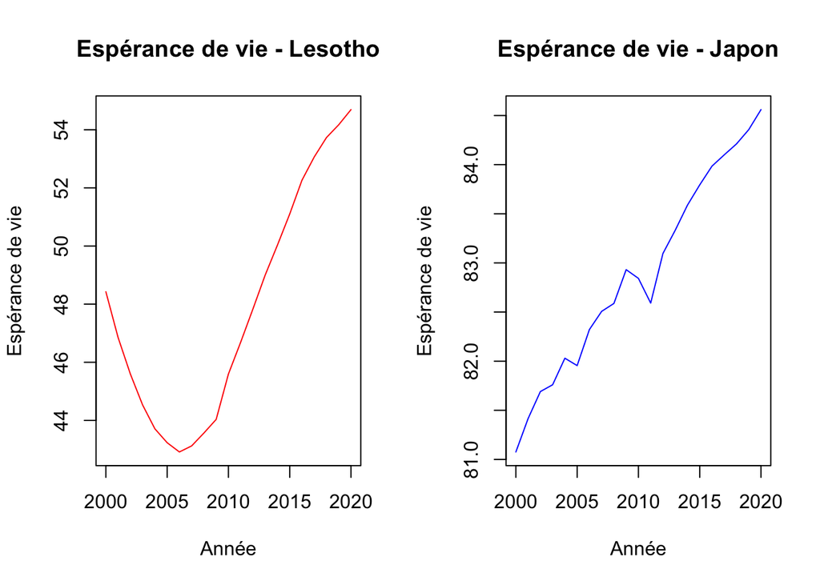

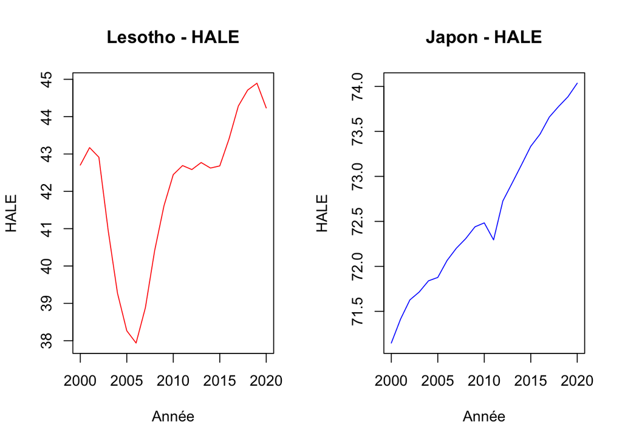

*Remarque* : **HALE** signifie **Health-Adjusted Life Expectancy**, soit en français « **espérance de vie en bonne santé** ».

On observe clairement une trajectoire divergente entre les deux pays. Au Lesotho, l’espérance de vie reste globalement faible et marquée par de fortes fluctuations, probablement liées à des facteurs sanitaires, économiques ou politiques. En revanche, le Japon présente une tendance stable et élevée, témoignant d’un système de santé performant et de meilleures conditions de vie.

Cette opposition est encore plus marquée lorsque l’on considère le HALE, qui met en lumière non seulement la durée de vie mais aussi sa qualité. Le fossé entre les deux pays se creuse davantage, confirmant que vivre longtemps ne suffit pas : vivre en bonne santé constitue un enjeu central des politiques de développement.

### 2.2.3 Etude de l’indice d’autonomisation politique des femmes

Avant de procéder à l’estimation du modèle complet, il est essentiel d’examiner plus en détail la distribution et l’évolution de l’indice d’autonomisation politique des femmes. Cela permet de mieux comprendre sa variabilité entre les pays et dans le temps, ainsi que son potentiel explicatif dans le cadre de notre analyse.

Pays avec le plus faible indice d’autonomisation des femmes

[output not shown]

Pays avec le plus fort indice d’autonomisation des femmes

| CountryName | moyenne_v2x_gender |
| --- | --- |
| Denmark | 0.9637143 |
| Germany | 0.9566190 |
| Sweden | 0.9511905 |
| Spain | 0.9509048 |
| Finland | 0.9492857 |
| New Zealand | 0.9469048 |

Pour illustrer les écarts en matière d’autonomisation politique des femmes, nous allons nous concentrer sur deux pays aux profils opposés : l’**Arabie Saoudite**, où la participation politique féminine reste historiquement très limitée, et le **Danemark**, souvent cité comme un modèle en matière d’égalité de genre. Cette comparaison permet de mettre en lumière la diversité des situations et l’évolution contrastée des droits politiques des femmes selon les contextes socio-politiques.

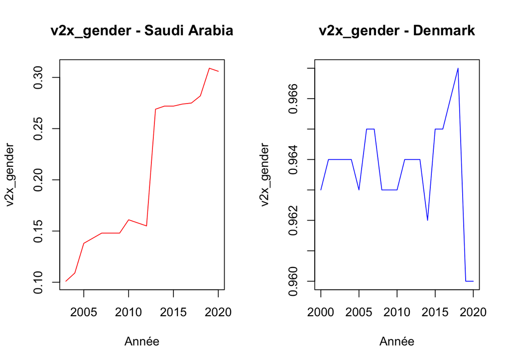

Les données révèlent un contraste frappant entre l’Arabie Saoudite et le Danemark.

Ces résultats illustrent comment des contextes socioculturels différents influencent la trajectoire vers l’égalité politique des femmes.

## 2.3 Etude des corrélations

Avant d’estimer des modèles économétriques, il est utile d’examiner les corrélations entre les variables d’intérêt. Cette étape permet d’identifier d’éventuelles relations linéaires et de repérer des signaux empiriques préliminaires sur les liens entre l’autonomisation politique des femmes et les indicateurs de santé maternelle.

Nous commençons par une analyse des corrélations au niveau mondial, en regroupant l’ensemble des observations disponibles, afin de dégager des tendances globales. Dans un second temps, nous affinons cette analyse en distinguant les pays, ce qui permet de mettre en évidence des hétérogénéités entre contextes nationaux. Cette approche comparée est particulièrement pertinente dans le cadre de données de panel, car elle aide à identifier si les corrélations observées globalement sont portées par certains pays spécifiques ou si elles sont généralisables.

### 2.3.1 Niveau mondial

L’analyse des corrélations à l’échelle mondiale permet d’examiner les liens entre variables sur l’ensemble du panel, sans distinction géographique, afin d’identifier les tendances générales qui se dégagent au niveau global. Le graphique ci-dessous illustre ces corrélations entre l’indice d’autonomisation politique des femmes et les indicateurs de santé retenus.

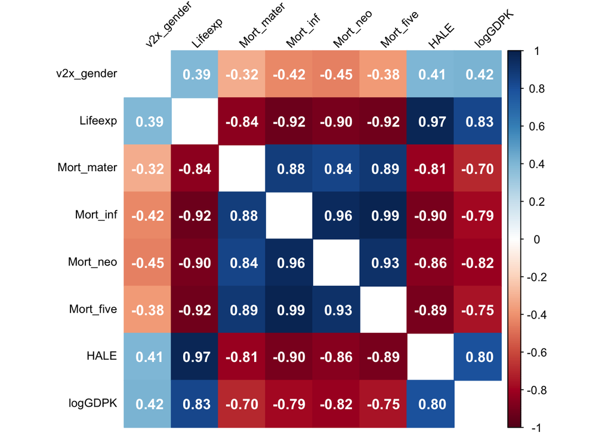

Ce graphique montre la corrélation entre plusieurs variables de développement socio-économique et de santé. On observe que l’espérance de vie (*Lifeexp*) est fortement corrélée de manière négative avec les différents taux de mortalité (maternelle, infantile, néonatale, etc.), ce qui signifie que plus la mortalité est élevée, plus l’espérance de vie diminue.  
À l’inverse, *Lifeexp* est fortement corrélée positivement avec l’espérance de vie en bonne santé (*HALE*) et le PIB par habitant (*logGDPK*), suggérant que de meilleures conditions économiques et sanitaires contribuent à une plus grande longévité.  
Enfin, l’indice d’autonomisation des femmes (*v2x_gender*) est positivement corrélé à ces indicateurs favorables, soulignant qu’un meilleur accès des femmes aux droits et aux opportunités est associé à un meilleur niveau de développement humain.

Afin de visualiser la nature et l’intensité des relations entre l’autonomisation politique des femmes et les indicateurs de santé, nous présentons ci-dessous plusieurs graphiques de dispersion croisant la variable v2x_gender avec chacun des indicateurs retenus. Ces représentations permettent d’observer les tendances générales ainsi que la présence éventuelle de relations linéaires.

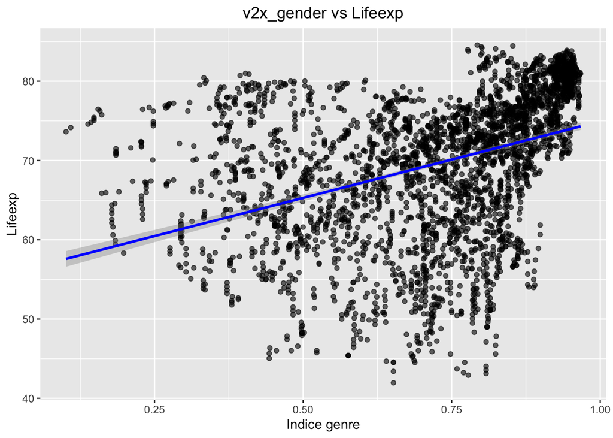

Le graphique démontre un lien significatif entre l’autonomisation politique des femmes (v2x_gender) et l’espérance de vie (Lifeexp) : plus la participation des femmes à la vie politique est importante, plus l’espérance de vie de la population augmente.

Afin d’évaluer la relation entre l’indice d’autonomisation politique des femmes (*v2x_gender*) et l’espérance de vie (*Lifeexp*), un test de corrélation de Pearson a été réalisé. Étant donné que la p-value du test est extrêmement faible (**p-value = 6.99e-126**), nous rejetons l’hypothèse nulle d’absence de corrélation. Cela indique qu’il existe une **corrélation significative** entre ces deux variables.

Nous passons maintenant à ce graphique, qui illustre la relation entre l’indice d’autonomisation politique des femmes (*v2x_gender*) et la mortalité maternelle (*Mort_mater*). Cette visualisation nous permet d’explorer plus en détail une éventuelle corrélation significative avec cette variable.

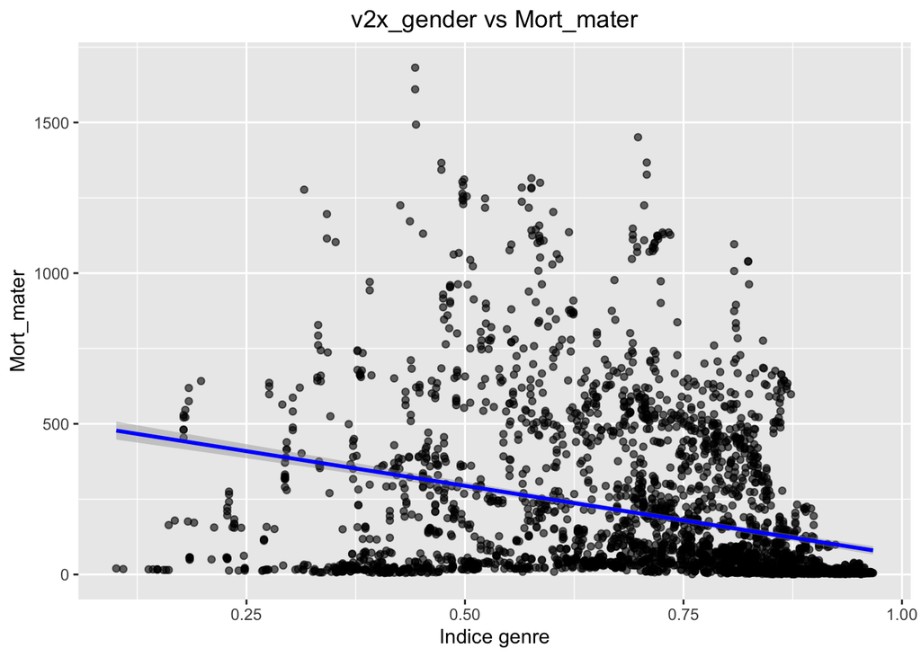

Ces résultats soulignent l’importance cruciale de l’inclusion politique des femmes comme levier pour améliorer la santé maternelle à l’échelle nationale.

Un test de corrélation de Pearson a été réalisé pour évaluer la relation entre l’indice d’autonomisation politique des femmes (*v2x_gender*) et la mortalité maternelle (*Mort_mater*). Les résultats indiquent une **corrélation statistiquement significative** avec une valeur p extrêmement faible (**p-value < 2.2e-16**), confirmant que la relation observée est hautement improbable d’être due au hasard.

Nous poursuivons avec ce graphique, qui explore la relation entre l’indice d’autonomisation politique des femmes (*v2x_gender*) et l’espérance de vie en bonne santé (*HALE*). Ce visuel nous aide à mieux comprendre comment l’autonomisation des femmes peut influencer la qualité de vie, au-delà de l’espérance de vie générale.

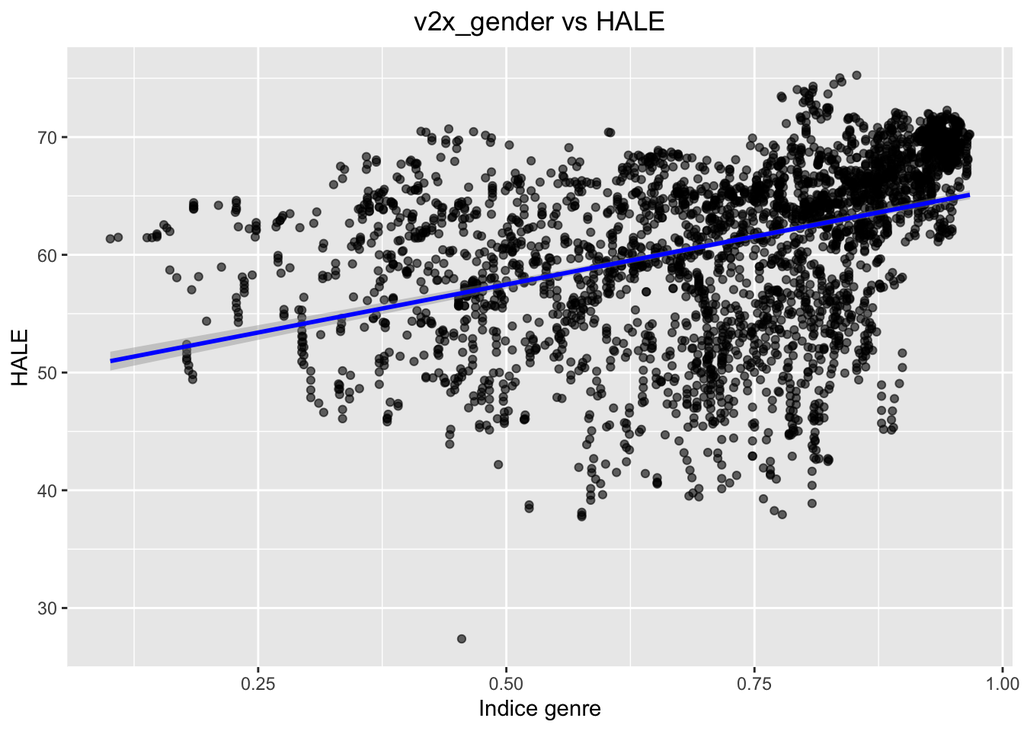

Le test de corrélation de Pearson entre l’indice d’autonomisation politique des femmes (*v2x_gender*) et l’espérance de vie corrigée de la santé (*HALE*) révèle une relation hautement significative étant donné que la **p-value = 1.045988e-135**. L’hypothèse nulle H0 est rejetée, confirmant que la corrélation entre v2x_gender et HALE est **statistiquement significative**.

### 2.3.2 Distinction par pays

Afin de mieux comprendre les variations contextuelles, nous procédons à une analyse différenciée des corrélations par pays. Cette approche permet de mettre en évidence les spécificités nationales et d’examiner si les relations observées au niveau mondial sont homogènes ou varient selon les pays.

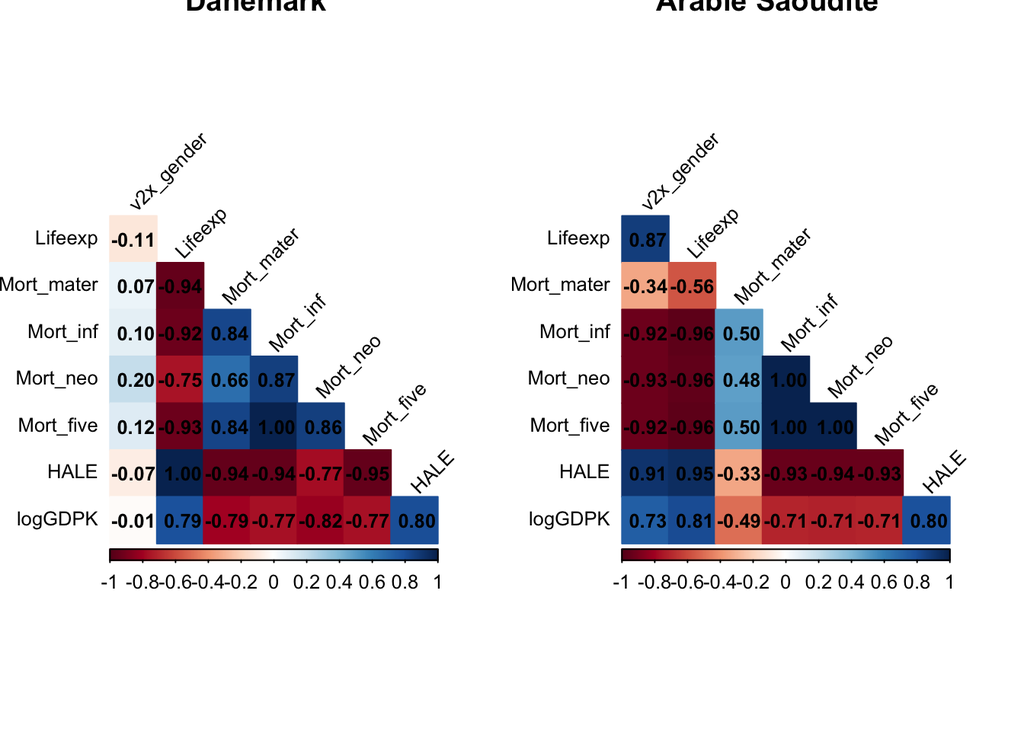

## 2.4 Régression linéaire multiple

Pour approfondir l’analyse des relations entre l’autonomisation politique des femmes et les indicateurs de santé, nous utilisons une régression linéaire multiple. Cette méthode permet de prendre en compte simultanément plusieurs variables explicatives et d’évaluer l’impact spécifique de chaque facteur tout en contrôlant pour les autres variables.

### 2.4.1 Sur l’ensemble des pays

Nous commençons par appliquer la régression linéaire multiple sur l’ensemble des pays, afin d’examiner les relations globales entre l’autonomisation politique des femmes et les indicateurs de santé. Cette analyse permet d’obtenir une vision générale des effets de l’autonomisation tout en tenant compte de la variation des autres facteurs.

```
##
## Call:
## lm(formula = v2x_gender ~ Lifeexp + Mort_mater + Mort_inf + Mort_neo +
##     Mort_five + HALE + logGDPK, data = data)
##
## Residuals:
##      Min       1Q   Median       3Q      Max
## -0.62489 -0.07502  0.04994  0.10430  0.35109
##
## Coefficients:
##               Estimate Std. Error t value Pr(>|t|)
## (Intercept)  6.599e-01  6.348e-02  10.395  < 2e-16 ***
## Lifeexp     -1.261e-02  1.612e-03  -7.827 6.60e-15 ***
## Mort_mater   5.983e-05  2.292e-05   2.610  0.00909 **
## Mort_inf    -8.394e-03  8.436e-04  -9.950  < 2e-16 ***
## Mort_neo    -3.882e-03  8.189e-04  -4.740 2.22e-06 ***
## Mort_five    4.573e-03  4.384e-04  10.431  < 2e-16 ***
## HALE         1.451e-02  1.599e-03   9.073  < 2e-16 ***
## logGDPK      1.945e-02  3.630e-03   5.357 9.00e-08 ***
## ---
## Signif. codes:  0 '***' 0.001 '**' 0.01 '*' 0.05 '.' 0.1 ' ' 1
##
## Residual standard error: 0.1579 on 3401 degrees of freedom
## Multiple R-squared:  0.2664, Adjusted R-squared:  0.2649
## F-statistic: 176.4 on 7 and 3401 DF,  p-value: < 2.2e-16
```

L’analyse révèle que l’autonomisation politique des femmes (*v2x_gender*) est significativement associée à plusieurs indicateurs clés. L’espérance de vie (*Lifeexp*, β=-0.0126, p<0.001) et la mortalité infantile (*Mort_inf*, **β=-0.0084**, **p<0.001**) montrent des effets négatifs, suggérant que de mauvais résultats sanitaires limitent l’accès des femmes au pouvoir politique. À l’inverse, le PIB (*logGDPK*, **β=0.0195, p<0.001**) et l’espérance de vie en bonne santé (*HALE*, **β=0.0145, p<0.001**) présentent des associations positives fortes. Notons que la mortalité maternelle (*Mort_mater*, **β=0.00006, p=0.009**) et celle des moins de 5 ans (*Mort_five*, **β=0.0046, p<0.001**) ont des effets opposés, reflétant peut-être des mécanismes différents selon le type de mortalité.

Bien que significatif (**F=176.4, p<0.001**), le modèle n’explique que 26.6% de la variance (R² ajusté=0.265), indiquant que d’autres facteurs institutionnels ou culturels jouent également un rôle crucial dans l’autonomisation politique des femmes. Ces résultats plaident pour des approches multidimensionnelles combinant développement économique, amélioration du système de santé et réformes politiques ciblées pour promouvoir l’égalité de genre.

### 2.4.2 Distinction par pays

pAfin d’affiner notre analyse, nous effectuons une régression linéaire multiple distincte pour deux pays spécifiques : le Danemark et l’Arabie Saoudite. Ces pays ont été choisis en raison de leurs contextes contrastés en matière d’autonomisation politique des femmes et de santé maternelle. Cette distinction permet de mieux comprendre comment les relations observées à l’échelle mondiale se déclinent dans des contextes nationaux très différents.

- *Pour le Danemark*

```
##
## Call:
## lm(formula = v2x_gender ~ Lifeexp + Mort_mater + Mort_inf + Mort_neo +
##     Mort_five + HALE + logGDPK, data = Denmark_data)
##
## Residuals:
##        Min         1Q     Median         3Q        Max
## -0.0026050 -0.0007571  0.0001244  0.0006779  0.0017150
##
## Coefficients:
##               Estimate Std. Error t value Pr(>|t|)
## (Intercept)  0.5227513  0.1990126   2.627   0.0209 *
## Lifeexp     -0.0072318  0.0025428  -2.844   0.0138 *
## Mort_mater   0.0007135  0.0009305   0.767   0.4569
## Mort_inf    -0.0175805  0.0106685  -1.648   0.1233
## Mort_neo     0.0055775  0.0038136   1.463   0.1673
## Mort_five    0.0163876  0.0089222   1.837   0.0892 .
## HALE         0.0116999  0.0041978   2.787   0.0154 *
## logGDPK      0.0166553  0.0162022   1.028   0.3227
## ---
## Signif. codes:  0 '***' 0.001 '**' 0.01 '*' 0.05 '.' 0.1 ' ' 1
##
## Residual standard error: 0.001395 on 13 degrees of freedom
## Multiple R-squared:  0.5508, Adjusted R-squared:  0.3089
## F-statistic: 2.277 on 7 and 13 DF,  p-value: 0.095
```

La régression montre que dans ce pays à haut revenu, seuls quelques facteurs influencent significativement l’autonomisation politique des femmes (*v2x_gender*).  
L’espérance de vie (*Lifeexp*, **β=-0.007, p=0.014**) a un effet négatif inattendu, peut-être dû à des spécificités locales ou à des effets de seuil dans une société déjà avancée. L’espérance de vie en bonne santé (*HALE*, **β=0.012, p=0.015**) montre quant à elle une corrélation positive, soulignant l’importance de la qualité de vie. La mortalité des moins de 5 ans (*Mort_five*, **β=0.016, p=0.089**) approche la significativité, suggérant un lien potentiel avec les politiques familiales.  
Cependant, le modèle global n’est que marginalement significatif (**p=0.095**) et explique seulement 30.9% de la variance (R² ajusté), indiquant que d’autres facteurs non mesurés (culturels, historiques ou politiques) jouent un rôle prépondérant dans l’autonomisation des femmes au Danemark. Ces résultats reflètent la complexité des dynamiques de genre dans les sociétés très égalitaires.

- *Pour l’Arabie Saoudite*

```
##
## Call:
## lm(formula = v2x_gender ~ Lifeexp + Mort_mater + Mort_inf + Mort_neo +
##     Mort_five + HALE + logGDPK, data = Saudi_Arabia_data)
##
## Residuals:
##       Min        1Q    Median        3Q       Max
## -0.033951 -0.005561 -0.000149  0.009357  0.029604
##
## Coefficients:
##              Estimate Std. Error t value Pr(>|t|)
## (Intercept) -0.831120   1.604372  -0.518   0.6157
## Lifeexp     -0.098350   0.034915  -2.817   0.0183 *
## Mort_mater  -0.006027   0.008679  -0.694   0.5033
## Mort_inf     0.306428   0.139837   2.191   0.0532 .
## Mort_neo     0.006483   0.184868   0.035   0.9727
## Mort_five   -0.290434   0.119378  -2.433   0.0353 *
## HALE         0.104191   0.042576   2.447   0.0344 *
## logGDPK      0.242690   0.278886   0.870   0.4046
## ---
## Signif. codes:  0 '***' 0.001 '**' 0.01 '*' 0.05 '.' 0.1 ' ' 1
##
## Residual standard error: 0.02126 on 10 degrees of freedom
## Multiple R-squared:  0.9521, Adjusted R-squared:  0.9187
## F-statistic: 28.43 on 7 and 10 DF,  p-value: 7.976e-06
```

## 2.5 Conclusion

# 3 Comparaison des effets de l’autonomisation politique des femmes sur la mortalité maternelle : pays développés vs pays en développement

## 3.1 Profils et indicateurs contrastés

L’évaluation du lien entre l’autonomisation politique des femmes et la mortalité maternelle met en lumière les contrastes marqués entre pays développés et pays en développement. Ces différences reflètent des écarts en matière de développement et de droits humains, avec des implications directes sur la santé maternelle. Dans les pays à faible revenu, la mortalité maternelle reste un défi majeur, aggravé par un accès limité aux services de santé, des normes discriminatoires, un faible niveau d’éducation, et une représentation politique insuffisante des femmes. Des violences domestiques et sexuelles, comme le souligne le rapport sur le développement humain en Afrique de 2016, renforcent cette vulnérabilité dans des contextes dominés par des structures patriarcales.

Les indicateurs de santé maternelle, tels que les taux de mortalité, sont plus préoccupants dans les pays où les femmes sont sous-représentées dans les instances décisionnelles. En Afrique, l’intégration des femmes dans le développement et la politique dépasse la question de l’égalité, devenant une condition essentielle pour améliorer les conditions de maternité. Des auteurs comme Benghabrit-Remaoun et Benzenine montrent que la lutte pour l’égalité des genres est un levier fondamental pour assurer la sécurité des femmes pendant la grossesse.

À l’inverse, des pays ayant un indice de développement humain élevé, comme le Maroc, enregistrent des taux de mortalité maternelle réduits grâce à des politiques inclusives qui intègrent les femmes dans les décisions politiques. Ces avancées démontrent que des investissements dans l’éducation et des politiques de santé inclusives renforcent non seulement l’autonomisation des femmes, mais également leur capacité à défendre leurs droits.

L’éducation, en particulier celle des filles, est un facteur clé pour briser le cycle de la pauvreté et réduire la mortalité maternelle. Une étude de l’OMS confirme que l’éducation génère des changements positifs dans les communautés, améliorant les droits des femmes et leur santé reproductive. Les pays avec des niveaux d’éducation féminine plus élevés affichent systématiquement des taux de mortalité maternelle plus bas.

Enfin, les initiatives de dialogue, comme celles organisées au Tchad, favorisent l’engagement politique des femmes et remettent en question des normes sociales restrictives. Ces espaces permettent d’intégrer leurs préoccupations dans les politiques publiques et de briser le cercle vicieux des inégalités, contribuant ainsi à réduire la mortalité maternelle.

En conclusion, les écarts entre pays développés et pays en développement illustrent l’impact crucial de l’autonomisation politique des femmes sur la santé maternelle. L’intégration de perspectives de genre dans les décisions politiques et la promotion des droits de santé sexuelle et reproductive sont essentielles pour transformer les conditions de vie des femmes. Des stratégies inclusives et éclairées peuvent renforcer leur autonomie, bénéficiant à toute la société.

## 3.2 Égalité de genre, représentation politique et développement économique

L’égalité de genre et la représentation politique des femmes sont essentielles au développement économique, en particulier dans les pays à faible revenu. L’absence de femmes dans les décisions politiques se traduit souvent par des politiques publiques inadaptées à leurs besoins, exacerbant les défis liés à la santé maternelle. Le rapport sur le développement humain en Afrique souligne que les violences systémiques auxquelles les femmes sont confrontées limitent leur accès aux services de santé nécessaires, notamment pendant la maternité.

Une meilleure représentation politique des femmes favorise des politiques inclusives, réduisant la mortalité maternelle. Des études, comme celles de Benghabrit-Remaoun et Benzenine, montrent que promouvoir l’égalité de genre, notamment dans l’éducation, améliore directement la sécurité des femmes durant la grossesse. Une corrélation claire existe entre un niveau d’éducation féminin élevé et une meilleure santé reproductive et maternelle.

Le Maroc illustre bien cet impact positif : en intégrant des politiques axées sur l’équité entre les sexes, il a réduit les taux de mortalité maternelle. Ces progrès soulignent comment des investissements dans l’éducation et les droits des femmes génèrent des bénéfices étendus, non seulement en matière de santé, mais aussi pour le développement global.

L’éducation des filles se révèle être un levier majeur d’autonomisation politique et de réduction de la mortalité maternelle. Selon l’OMS, elle déclenche des changements sociaux favorables aux droits des femmes et à leur accès aux soins. Ainsi, les politiques éducatives visant à rehausser le statut des femmes sont fondamentales pour renforcer leurs droits et améliorer leur santé.

Des initiatives comme celles organisées au Tchad montrent que les espaces de dialogue sur l’autonomisation des femmes et l’égalité des genres renforcent leurs réseaux, leur permettant de s’impliquer davantage dans les processus décisionnels. Ces efforts contribuent à transformer les normes sociales, en intégrant les préoccupations des femmes dans les politiques publiques.

En conclusion, la corrélation entre égalité de genre, représentation politique et développement économique est indéniable. L’autonomisation des femmes est non seulement un impératif de justice sociale, mais aussi un levier stratégique pour réduire la mortalité maternelle. L’intégration des femmes dans les instances décisionnelles est essentielle pour construire un modèle de développement inclusif, bénéfique à l’ensemble de la société.

## 3.3 Le rôle différencié de l’autonomisation dans les pays en développement et leurs apports

L’autonomisation politique des femmes varie selon les contextes socioculturels et politiques propres à chaque pays en développement, influençant différemment les efforts pour réduire la mortalité maternelle. L’absence de représentation féminine dans les instances décisionnelles perpétue des normes et pratiques nuisibles au bien-être des femmes, notamment les violences domestiques et les mutilations génitales, identifiées comme des obstacles majeurs dans le Rapport sur le développement humain en Afrique.

Cependant, l’autonomisation ne se limite pas à l’accès aux sphères politiques : elle inclut l’éducation, la santé et les droits légaux. Les pays valorisant l’éducation des filles observent une meilleure santé reproductive et une réduction des complications liées à la maternité. Une éducation élevée permet aux femmes de mieux s’exprimer, de revendiquer leurs droits et de participer à des décisions politiques qui influencent directement leur santé et celle de leur communauté.

Le Maroc, par exemple, démontre comment des politiques axées sur l’égalité des genres peuvent réduire la mortalité maternelle. En investissant dans l’éducation, l’accès aux soins et des lois promouvant l’égalité, ce pays a réalisé des progrès notables en matière de santé maternelle, prouvant que l’autonomisation des femmes bénéficie à l’ensemble de la société.

De plus, les initiatives de dialogue sur l’autonomisation et l’égalité des genres, comme celles menées au Tchad, renforcent les capacités des femmes à influencer les politiques publiques. Ces espaces favorisent un changement des normes sociales et ouvrent la voie à des politiques inclusives, sensibles aux besoins des femmes.

En conclusion, l’autonomisation des femmes constitue un levier stratégique pour réduire la mortalité maternelle dans les pays en développement. Les droits en matière de santé sexuelle et reproductive, combinés à des efforts pour promouvoir l’égalité des genres, sont essentiels pour réduire les inégalités et améliorer les résultats en matière de santé. Lorsque les femmes sont soutenues politiquement et socialement, les bénéfices se répercutent sur toute la société, offrant des perspectives plus justes et plus saines.

## 3.4 Lien entre contexte politique et mortalité maternelle

L’autonomisation politique des femmes est profondément liée au contexte socio-politique et économique des pays, et ce contexte dépend du niveau de développement. De manière générale, les pays développés, souvent plus démocratiques, offrent un cadre plus favorable à l’autonomisation des femmes, ce qui peut indirectement influencer la mortalité maternelle.

### 3.4.1 Les pays développés : cas du Japon, de la Finlande et des États-Unis

Dans les démocraties développées comme le Japon, la Finlande et les États-Unis, l’autonomisation politique des femmes est soutenue par des structures démocratiques. Par exemple :

• Japon : Classé 20ᵉ démocratie mondiale avec un indice démocratique de 8.15/10, il affiche un indice d’autonomisation politique des femmes de 0.801 et une mortalité maternelle de 5 décès pour 100 000 naissances. Le système médical très développé et centralisé favorise une meilleure prise en charge des femmes enceintes.  
• Finlande : 3ᵉ démocratie mondiale, avec un indice d’autonomisation élevé (0.952), mais une mortalité maternelle légèrement supérieure (8 décès pour 100 000). Ici, un système de soins plus décentralisé et communautaire, bien que démocratique, pourrait expliquer cette différence.  
• États-Unis : Bien que riches et démocratiques (28ᵉ place mondiale, indice 7.85), ils affichent une mortalité maternelle élevée (19 décès pour 100 000). Les inégalités structurelles (notamment raciales), l’absence de couverture médicale universelle et les disparités territoriales en matière de santé reproductive contribuent à ce paradoxe.

Ces cas montrent que la démocratie et l’autonomisation des femmes favorisent une meilleure prise en charge des mères, mais d’autres facteurs comme les inégalités sociales et le modèle de soins influencent fortement les résultats.

### 3.4.2 Les pays en développement : cas du Bangladesh et de l’Éthiopie

Dans les pays en développement, la faiblesse des institutions démocratiques limite l’impact de l’autonomisation politique des femmes sur la mortalité maternelle :

• Bangladesh : Avec un régime hybride (indice démocratique de 4.44/10) et un indice d’autonomisation de 0.688, la mortalité maternelle atteint 172 décès pour 100 000 naissances. Malgré l’existence de quotas réservant 50 sièges parlementaires aux femmes, leur influence politique reste limitée, en particulier pour les femmes rurales. Le sous-financement des infrastructures médicales aggrave la situation.  
• Éthiopie : Classée comme régime autoritaire (indice de 3.24), avec un faible indice d’autonomisation (0.641) et une mortalité maternelle alarmante (312 décès pour 100 000). Le pouvoir centralisé, les conflits internes (ex. guerre du Tigré), et le manque d’investissement dans la santé reproductive entravent l’accès aux soins pour les femmes, notamment en zones rurales.  
Ces exemples illustrent que l’absence de démocratie, la faiblesse institutionnelle, les conflits et les inégalités structurelles empêchent l’autonomisation politique des femmes d’avoir un impact significatif sur la santé maternelle.

## 3.5 Conclusion

L’autonomisation politique des femmes et la qualité démocratique des pays influencent la mortalité maternelle, mais de façon indirecte et non systématique.  
Dans les pays développés, des facteurs tels que les modèles de soins, l’accès aux infrastructures médicales, et les inégalités sociales jouent un rôle déterminant. Dans les pays en développement, les limites institutionnelles, les conflits, et les faibles investissements en santé reproductive restent des obstacles majeurs.

Réduire la mortalité maternelle exige donc une approche globale intégrant la démocratisation, l’autonomisation des femmes, et des politiques publiques inclusives axées sur les besoins concrets des femmes. Cela inclut le renforcement des infrastructures de santé, la lutte contre les inégalités structurelles, et la création de conditions sociopolitiques qui permettent aux femmes d’exercer pleinement leur pouvoir décisionnel, tant dans les sphères politiques que communautaires.

# 4 Conclusion

L’autonomisation politique des femmes joue un rôle crucial dans l’amélioration des politiques de santé maternelle et la réduction de la mortalité maternelle à l’échelle mondiale, mais elle n’est ni le seul ni un facteur universellement suffisant. Elle permet souvent de prioriser la santé reproductive grâce à des mesures comme l’instauration de budgets genrés, de lois favorisant l’égalité et d’une meilleure visibilité des enjeux liés à la maternité. Cela se traduit par la mise en place d’infrastructures facilitant l’accès aux soins physiques et psychologiques des femmes, depuis la conception jusqu’à l’après-accouchement.

Cependant, l’impact de cette autonomisation dépend fortement du contexte dans lequel elle s’exerce. Dans les pays développés comme la Finlande et le Japon, des environnements démocratiques solides combinés à des ressources adéquates permettent une influence notable des femmes en politique sur les priorités de santé maternelle. À l’inverse, dans des pays en développement comme le Bangladesh et l’Éthiopie, où l’autonomisation politique reste souvent formelle ou limitée par des régimes autoritaires et des conflits internes, ses effets restent faibles, reflétant des taux de mortalité maternelle élevés.

Il est important de noter que même dans des démocraties avancées, comme les États-Unis, la mortalité maternelle peut demeurer élevée lorsque des inégalités structurelles, telles que le racisme systémique ou un accès inégal aux soins, persistent. Cela montre que la représentation politique féminine et la démocratisation doivent être accompagnées d’efforts pour renforcer les systèmes de santé et lutter contre les discriminations structurelles.

Notre analyse a confirmé quatre hypothèses principales :

En conclusion, la réduction durable de la mortalité maternelle repose sur un triptyque indissociable : une démocratisation effective, une représentation politique féminine significative et un investissement conséquent dans la santé reproductive. Ce cadre global doit également intégrer la lutte contre les inégalités structurelles pour garantir un accès équitable aux soins à toutes les femmes, indépendamment de leur contexte politique, social ou économique.

## Bibliographie

*Introduction*  
1. *Organisation mondiale de la Santé [OMS], 2023*  
2. *INSERM, 2021 ; OMS, 2013*  
3. *Miller, 2008*  
4. *Bhalotra, Clots-Figueras, & Iyer, 2014*  
5. *Sen & Östlin, 2008 ; UN Women, 2020*

*Sources et références partie I*  
1. *E Grossetti (2024)*. Mortalité maternelle chez les femmes avec vulnérabilité sociale en France 2016–2018.  
[Lien](https://www.sciencedirect.com/science/article/pii/S2352580024000777)  
2. *(s.d.). LIBÉRER LE POTENTIEL DES FEMMES ET DES FILLES… (2022)*  
[Lien](https://openknowledge.worldbank.org/server/api/core/bitstreams/1b0d459f-edf9-4ae8-a6f2-d4482d2815ca/content)  
3. *N Benghabrit-Remaoun, B Benzenine (2012)*. Les femmes africaines à l’épreuve du développement.  
[Lien](https://m.africabib.org/rec.php?RID=369218116&DB=w)  
4. *Bamada.net (NaN)*. Lutte pour la réduction de la mortalité maternelle…  
[Lien](https://bamada.net/lutte-pour-la-reduction-de-la-mortalite-maternelle-et-infantile-fenajfa-plaide-pour-le-decret-05-350)  
5. *drc.unfpa.org (2024)*. Forum des femmes leaders… RDC.  
[Lien](https://drc.unfpa.org/fr/events/forum-des-femmes-leaders-sur-la-r%C3%A9duction-de-la-mortalit%C3%A9-maternelle-et-n%C3%A9onatale-l%C3%A9galit%C3%A9)

*World Bank Blogs (2022)*. Les données, un bon moyen pour accélérer l’égalité.  
[Lien](https://blogs.worldbank.org/fr/opendata/les-donnees-un-bon-moyen-pour-accelerer-legalite)

*Sources et références partie III*  
1. *A Undp (2016)*. Rapport sur le développement humain en Afrique 2016 Accélérer les progrès en faveur de l’égalité des genres et de l’autonomisation des femmes en Afrique.  
[Lien](https://econpapers.repec.org/paper/agsundpar/267637.htm)  
2. *N Benghabrit-Remaoun, B Benzenine (2012)*. Les femmes africaines à l’épreuve du développement.  
[Lien](https://m.africabib.org/rec.php?RID=369218116&DB=w)  
3. *World Health Organization (2023)*. Tendances de la mortalité maternelle de 2000 à 2020: estimations de l’OMS, de l’UNICEF, du FNUAP, du Groupe de la Banque mondiale et de la Division de ….  
[Lien](https://books.google.com/books?hl=en&lr=&id=cI8OEQAAQBAJ&oi=fnd&pg=PA7&dq=%C3%89galit%C3%A9+de+genre+mortabilit%C3%A9+maternelle+autonomisation&ots=oCKaVaJALl&sig=nLzlzxp2CR7HdTRs-LM8fWOW6O8)  
4. *Le Matin.ma (NaN)*. Avancée historique : Le Maroc intègre la catégorie des pays à développement humain élevé (PNUD).  
[Lien](https://lematin.ma/nation/le-maroc-integre-la-categorie-des-pays-a-developpement-humain-eleve-pnud/277894)  
5. *www.unfpa.org (2024)*. 5 faits essentiels sur l’égalité en matière de santé et de droits sexuels et reproductifs aujourd’hui.  
[Lien](https://www.unfpa.org/fr/news/5-faits-essentiels-sur-l%E2%80%99%C3%A9galit%C3%A9-en-mati%C3%A8re-de-sant%C3%A9-et-de-droits-sexuels-et-reproductifs)  
6. *African Development Bank Group (2018)*. Tchad : Dialogue sur l’autonomisation des femmes et l’égalité des genres.  
[Lien](https://www.afdb.org/en/news-and-events/tchad-dialogue-sur-lautonomisation-des-femmes-et-legalite-des-genres-18824)  
7. *Democracy Index 2024* - Economist Intelligence Unit  
8. *Maternal mortality ratio (modeled estimate, per 100,000 live births) - Bangladesh | Data*  
9. *Jatiya Sangsad* — Wikipédia